# Phasors

The current delivered by the source in the circuit is $10\,\cos\,(120\,\pi\,t - 15^{\circ})$. Load impedance $Z_1$ consumes $300\,$W active power, and load $Z_2$ delivers $300\,$VAR reactive power.

1. Find $Z_1$ and $Z_2$.
2. Calculate ${\bf{I}}_1$ and ${\bf{I}}_2$.
3. Draw the phasor diagrams showing KCL.

(Follow the convention that $\cos\,(\omega \,t)$ corresponds to the phasor $1\,\angle {0}$.)

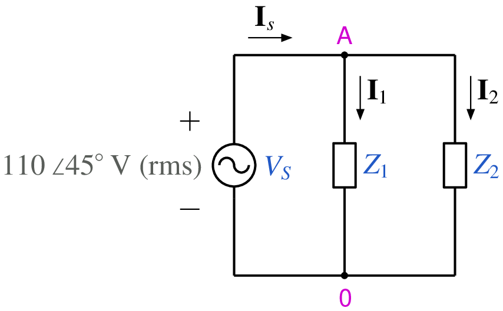

```python
from IPython.display import Image
Image(filename =r'phasor_7_fig_1.png', width=320)
```

```python
# RL circuit
# run this cell to view the circuit file.
%pycat phasor_7_orig.in
```

We now replace strings such as \$Z1_mag with the values of our choice by running the python script given below. It takes an existing circuit file `phasor_7_orig.in` and produces a new circuit file `phasor_7.in`, after replacing \$Z1_mag, etc, with the values of our choice.

```python
import gseim_calc as calc
s_Z1_mag       = '10'  # to be changed by user
s_Z1_theta_deg = '40'  # to be changed by user
s_Z2_mag       = '20'  # to be changed by user
s_Z2_theta_deg = '-30' # to be changed by user
l = [
  ('$Z1_mag', s_Z1_mag),
  ('$Z1_theta_deg', s_Z1_theta_deg),
  ('$Z2_mag', s_Z2_mag),
  ('$Z2_theta_deg', s_Z2_theta_deg),
]
calc.replace_strings_1("phasor_7_orig.in", "phasor_7.in", l)
print('phasor_7.in is ready for execution')
```

```
phasor_7.in is ready for execution
```

**Execute the following cell to run GSEIM on phasor_7.in.**

```python
import os
import dos_unix
# uncomment for windows:
#dos_unix.d2u("phasor_7.in")
os.system('run_gseim phasor_7.in')
```

```
Circuit: filename = phasor_7.in
GSEIM: Program completed.
```

```
0
```

The last step (i.e., running `GSEIM` on `phasor_7.in`) creates the data file `phasor_7.dat` in the same directory. We can now use the python code below to compute and display the quantities of interest.

```
filename: phasor_7.dat
phasors in rectangular form:
IZ1: (  15.50,    1.36)
IZ2: (   2.01,    7.51)
SZ1: ( 926.87,  777.74)
SZ2: ( 523.92, -302.49)
Is: (  17.51,    8.87)
Vs: ( 110.00,  110.00)
phasors in polar form:
IZ1: magnitude:   15.56, angle:    5.00 deg
IZ2: magnitude:    7.78, angle:   75.00 deg
SZ1: magnitude: 1209.95, angle:   40.00 deg
SZ2: magnitude:  604.97, angle:  -30.00 deg
Is: magnitude:   19.63, angle:   26.86 deg
Vs: magnitude:  155.56, angle:   45.00 deg
```

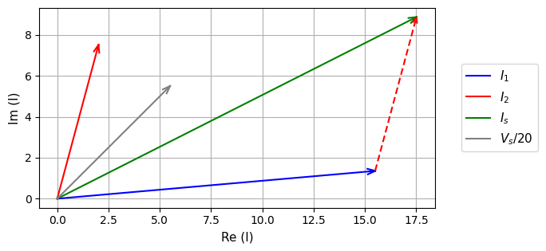

```python
import numpy as np
import gseim_calc as calc
import matplotlib.pyplot as plt
from matplotlib.ticker import (MultipleLocator, AutoMinorLocator)
from setsize import set_size

rad_to_deg = 180.0/np.pi

slv = calc.slv("phasor_7.in")

i_slv = 0
i_out = 0
filename = slv.l_filename_all[i_slv][i_out]
print('filename:', filename)
u = np.loadtxt(filename)

IZ1 = slv.get_scalar_complex_1(i_slv, i_out, "IZ1", u)
IZ2 = slv.get_scalar_complex_1(i_slv, i_out, "IZ2", u)
SZ1 = slv.get_scalar_complex_1(i_slv, i_out, "SZ1", u)
SZ2 = slv.get_scalar_complex_1(i_slv, i_out, "SZ2", u)
Is  = slv.get_scalar_complex_1(i_slv, i_out, "Is",  u)
Vs  = slv.get_scalar_complex_1(i_slv, i_out, "Vs",  u)

s_format = "%7.2f"

print('phasors in rectangular form:')

calc.print_complex_rect('IZ1', IZ1, s_format)
calc.print_complex_rect('IZ2', IZ2, s_format)
calc.print_complex_rect('SZ1', SZ1, s_format)
calc.print_complex_rect('SZ2', SZ2, s_format)
calc.print_complex_rect('Is',  Is, s_format)
calc.print_complex_rect('Vs',  Vs, s_format)

print('phasors in polar form:')

calc.print_complex_polar('IZ1', IZ1, s_format)
calc.print_complex_polar('IZ2', IZ2, s_format)
calc.print_complex_polar('SZ1', SZ1, s_format)
calc.print_complex_polar('SZ2', SZ2, s_format)
calc.print_complex_polar('Is',  Is, s_format)
calc.print_complex_polar('Vs',  Vs, s_format)

Vs1 = Vs/20.0

l_colors = ["blue", "red", "green", "grey", "dodgerblue", "tomato"]

l1 = []
l1_labels = []

color_IZ1  = calc.phasor_append_1a(l1, l1_labels, IZ1, "$I_1$",    l_colors)
color_IZ2  = calc.phasor_append_1a(l1, l1_labels, IZ2, "$I_2$",    l_colors)
color_Is   = calc.phasor_append_1a(l1, l1_labels, Is,  "$I_s$",    l_colors)
color_Vs1  = calc.phasor_append_1a(l1, l1_labels, Vs1, "$V_s/20$", l_colors)

theta_deg = 20.0
length_arrow = calc.phasor_3(l1, 0.02)
l1_arrow = calc.phasor_2(l1, theta_deg, length_arrow, 0.2)

l2 = []
l2_colors = []

calc.phasor_append_2(l2, l2_colors, IZ1, (IZ1 + IZ2), color_IZ2)

l2_arrow = calc.phasor_2(l2, theta_deg, length_arrow, 0.2)

fig, ax = plt.subplots()
ax.set_aspect('equal', adjustable='box')
ax.grid()

for i, l_dummy in enumerate(l1_arrow):
    for k, t in enumerate(l_dummy):
        if (k == 0):
            ax.plot(t[0],t[1], color=l_colors[i], label=l1_labels[i])
        else:
            ax.plot(t[0],t[1], color=l_colors[i])

for i, l_dummy in enumerate(l2_arrow):
    for k, t in enumerate(l_dummy):
        ax.plot(t[0],t[1], color=l2_colors[i], linestyle='--', dashes=(4, 2))

calc.revise_axis_limits_1(ax, 3.0)
ax.legend(loc='center left', fontsize=11, bbox_to_anchor=(1.05, 0.5))

plt.xlabel('Re (I)', fontsize=11)
plt.ylabel('Im (I)', fontsize=11)
plt.show()
```

```
filename: phasor_7.dat
phasors in rectangular form:
SZ1: ( 926.87,  777.74)
SZ2: ( 523.92, -302.49)
SVs: (1450.79,  475.25)
phasors in polar form:
SZ1: magnitude: 1209.95, angle:   40.00 deg
SZ2: magnitude:  604.97, angle:  -30.00 deg
SVs: magnitude: 1526.65, angle:   18.14 deg
```

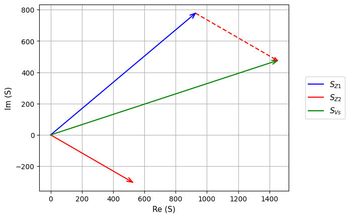

```python
import numpy as np
import gseim_calc as calc
import matplotlib.pyplot as plt
from matplotlib.ticker import (MultipleLocator, AutoMinorLocator)
from setsize import set_size

rad_to_deg = 180.0/np.pi

slv = calc.slv("phasor_7.in")

i_slv = 0
i_out = 0
filename = slv.l_filename_all[i_slv][i_out]
print('filename:', filename)
u = np.loadtxt(filename)

SZ1 = slv.get_scalar_complex_1(i_slv, i_out, "SZ1", u)
SZ2 = slv.get_scalar_complex_1(i_slv, i_out, "SZ2", u)
SVs = slv.get_scalar_complex_1(i_slv, i_out, "SVs", u)

s_format = "%7.2f"

print('phasors in rectangular form:')

calc.print_complex_rect('SZ1', SZ1, s_format)
calc.print_complex_rect('SZ2', SZ2, s_format)
calc.print_complex_rect('SVs', SVs, s_format)

print('phasors in polar form:')

calc.print_complex_polar('SZ1', SZ1, s_format)
calc.print_complex_polar('SZ2', SZ2, s_format)
calc.print_complex_polar('SVs', SVs, s_format)

l_colors = ["blue", "red", "green", "grey", "dodgerblue", "tomato"]

l1 = []
l1_labels = []

color_SZ1 = calc.phasor_append_1a(l1, l1_labels, SZ1, "$S_{Z1}$", l_colors)
color_SZ2 = calc.phasor_append_1a(l1, l1_labels, SZ2, "$S_{Z2}$", l_colors)
color_SVs = calc.phasor_append_1a(l1, l1_labels, SVs, "$S_{Vs}$", l_colors)

theta_deg = 20.0
length_arrow = calc.phasor_3(l1, 0.02)
l1_arrow = calc.phasor_2(l1, theta_deg, length_arrow, 0.2)

l2 = []
l2_colors = []

calc.phasor_append_2(l2, l2_colors, SZ1, (SZ1 + SZ2), color_SZ2)

l2_arrow = calc.phasor_2(l2, theta_deg, length_arrow, 0.2)

fig, ax = plt.subplots()
ax.set_aspect('equal', adjustable='box')
ax.grid()

for i, l_dummy in enumerate(l1_arrow):
    for k, t in enumerate(l_dummy):
        if (k == 0):
            ax.plot(t[0],t[1], color=l_colors[i], label=l1_labels[i])
        else:
            ax.plot(t[0],t[1], color=l_colors[i])

for i, l_dummy in enumerate(l2_arrow):
    for k, t in enumerate(l_dummy):
        ax.plot(t[0],t[1], color=l2_colors[i], linestyle='--', dashes=(4, 2))

calc.revise_axis_limits_1(ax, 3.0)
ax.legend(loc='center left', fontsize=11, bbox_to_anchor=(1.05, 0.5))

plt.xlabel('Re (S)', fontsize=11)
plt.ylabel('Im (S)', fontsize=11)
plt.show()
```

This notebook was contributed by **Prof. Nakul Narayanan K**, Govt. Engineering College, Thrissur. He may be contacted at nakul@gectcr.ac.in.